# Review template

Yann

12/07/23

# Data cleaning checks

version 1.1.0.

This review is separated into two parts *Data checks* and *Cleaning log*:  
- The first part will performed different check on the dataset, depending on the information available (time, outliers, shortest path, etc.).  
- The second part will look at how the cleaning was performed. It will first look if the values from the cleaning log are correctly changed in the clean data, and then it will look at differences between the raw data and clean data and see if anything was not logged into the cleaning log.

The summary can be found in the output folder.

```r
library(tidyverse)
library(knitr)
library(kableExtra)
#install.packages("openxlsx")
library(openxlsx)
#install.packages("remotes")
#remotes::install_github("ellieallien/cleaninginspectoR")
source("utils/rendering.R")
source("utils/check_cleaning.R")
file.remove("outputs/dataset_with_check.xlsx", "outputs/review_cleaning_part2.xlsx", "outputs/review_cleaning_log_part1.xlsx")
```

```
## [1] TRUE TRUE TRUE
```

```r
library(readxl)
#The only section that should be changed.
file <- "C:/Users/lisa.reiners/OneDrive - ACTED/Documents/R-training/Codigos de R/review_ajustado_lisa/inputs/IRQ2301_Winter_cash_assistance_dataset.xlsx"
raww <- read_excel(file, guess = 10000, sheet = "Raw Data")

cleann <- read_excel(file, guess = 50000, sheet="Clean Data")
cleann$start<-strftime(cleann$start,"%Y-%m-%dT%H:%M:%S.000%z")
cleann$end<-strftime(cleann$end,"%Y-%m-%dT%H:%M:%S.000%z")


logg <- read_excel(file, guess = 50000,sheet = "Cleaning Log")
colnames(logg) <- logg[1,]
logg <- logg[-1, ]


dell <- read_excel(file, guess = 50000, sheet = "Deletions")

questions <- read_excel(file, sheet="Kobo")

choices <- read_excel(file, sheet = "Choice")

# Create a list to store datasets
datasetList <- list(raww = raww, cleann = cleann,logg = logg, dell = dell)

# Iterate through the datasets in the list
for (name_datasets in names(datasetList)) {
  dataset <- datasetList[[name_datasets]]  # Get the current dataset

  have_uuid <- FALSE  # Flag to track if there are duplicate uuid columns
  column_names <- colnames(dataset)  # Get all column names
  duplicate_columns <- duplicated(column_names)  # Find duplicate column names

  # Check if there are any duplicate columns
  if (any(duplicate_columns)) {
    duplicate_column_names <- column_names[duplicate_columns]  # Save the names of the duplicated columns

    # Iterate through the duplicated column names
    for (value in duplicate_column_names) {
      if (value == "uuid" || value == "_uuid" || value == "__uuid") {
        have_uuid <- TRUE
        print(paste("There are duplicated uuid columns. Please choose the correct one and delete the incorrect one. It is in the:", name_datasets))
      }
    }
  }

  # If there are no duplicate uuid columns
  if (!have_uuid) {
    column_found <- FALSE  # Flag to track if the column is found
    uuid_name_datasets <- NULL  # Variable to store the name of the UUID column

    # Iterate through the column names
    for (column in column_names) {
      if (column == "uuid" || column == "_uuid" || column == "__uuid") {
        uuid_name_datasets <- column
        column_found <- TRUE
        break  # Stop the loop if the column is found
      }
    }

    if (column_found) {
      #print(paste("The column 'uuid' is found in:", name_datasets, "dataset"))
      #print(uuid_name_datasets)

      # Create a dynamic variable name to store the uuid_name_datasets value
      assign(paste("uuid_", name_datasets, sep = ""), uuid_name_datasets)

    } else {
      print(paste("Column 'uuid' not found!", name_datasets, "dataset"))
    }
  }
}

#Prueba
#uuid_cleann
#uuid_logg

#names from the cleaning log
colname_logg <- colnames(logg)
var_logg <- NULL
old_value_logg <- NULL

for (col_name in colname_logg) {
  if (grepl("question", tolower(col_name))) {
    var_logg <- col_name
    #print(var_logg)
  }
  if (grepl("old", tolower(col_name))) {
    old_value_logg <- col_name
    #print(old_value_logg)
  }
  if (grepl("new", tolower(col_name))) {
    new_value_logg <- col_name
    #print(new_value_logg)
  }
}

#prueba
#new_value_logg

#####################################
# uuid_raww <- "_uuid"
# uuid_cleann <- "_uuid"
# uuid_logg <- "uuid"
# uuid_dell <- "_uuid"
#
# #names from the cleaning log
# var_logg <- "Question"
# old_value_logg <- "Old Value"
# new_value_logg <- "New Value"

#tests to include  TRUE / FALSE
check_for_duplicates <- TRUE
check_for_pii <- TRUE
check_for_time <- TRUE
check_for_shortest_path <- TRUE
check_for_outliers <- TRUE
check_for_logical <- TRUE
check_for_others <- TRUE
check_for_deletions <- TRUE
check_for_etc <- TRUE
check_for_cleaning_log <- TRUE
check_for_raw_clean_data <- TRUE
```

```r
#create a binding key for the cleaning log
logg <- logg %>%
  mutate(binding = paste0(!!sym(uuid_logg), "-/-", !!sym(var_logg)))
list_log <- list()
```

## 1. Data checks

### Checks for duplicates

```r
if (check_for_duplicates) {
  duplicate_log <- cleaninginspectoR::find_duplicates(cleann, uuid_cleann) %>%
    mutate(uuid = cleann[[uuid_cleann]][index])

  list_log$duplicate_log <- duplicate_log

  print_log(duplicate_log, "No duplicates found")

}
```

```
## No duplicates found
```

### Checks for PII

```r
if (check_for_pii) {
  pii_log <- cleaninginspectoR::sensitive_columns(cleann)

  list_log$pii_log <- pii_log

  print_log(pii_log, "No sensitive columns found")
}
```

| index | value | variable | has_issue | issue_type |
| --- | --- | --- | --- | --- |
| NA | NA | telephone_number | TRUE | Potentially sensitive information. Please ensure all PII is removed |
| NA | NA | phone_number_new | TRUE | Potentially sensitive information. Please ensure all PII is removed |
| NA | NA | phone_number_new2 | TRUE | Potentially sensitive information. Please ensure all PII is removed |
| NA | NA | phone_number | TRUE | Potentially sensitive information. Please ensure all PII is removed |
| NA | NA | phone_1 | TRUE | Potentially sensitive information. Please ensure all PII is removed |
| NA | NA | phone_2 | TRUE | Potentially sensitive information. Please ensure all PII is removed |
| NA | NA | phone_3 | TRUE | Potentially sensitive information. Please ensure all PII is removed |
| NA | NA | phone_4 | TRUE | Potentially sensitive information. Please ensure all PII is removed |
| NA | NA | phone_5 | TRUE | Potentially sensitive information. Please ensure all PII is removed |
| NA | NA | phone_6 | TRUE | Potentially sensitive information. Please ensure all PII is removed |

*NOTE*:  
- Only looks for the words “GPS, gps, phone, Latitude, Longitude, Phone” in the names of the dataset.  
- It does not check the value in those columns

### Check for time

```r
lower_treshold <- 15
higher_threshold <- 100

if (check_for_time) {
  time_log <- cleaninginspectoR::check_time(cleann, duration_threshold_lower = lower_treshold,
                                          duration_threshold_upper = higher_threshold)

  list_log$time_log <- time_log

  print_log(time_log, "No time sensitive interviews found")

}
```

| index | value | variable | has_issue | issue_type |
| --- | --- | --- | --- | --- |
| 7f86193c-35b3-403b-8a6a-4efb9e5d8274 | 11.56 | Completion Duration (min) | TRUE | form duration too short |
| 27a36250-a43b-42c1-891c-8a9750068193 | 10.23 | Completion Duration (min) | TRUE | form duration too short |
| 9aeb1bac-26ca-45da-b50c-98d08f6160ee | 14.35 | Completion Duration (min) | TRUE | form duration too short |
| a23f9e12-02a5-41f6-b6c2-f2ef680e33f3 | 2.78 | Completion Duration (min) | TRUE | form duration too short |
| 1dd83ff8-5f1c-4401-9f73-5ac65fa9e68b | 4.72 | Completion Duration (min) | TRUE | form duration too short |
| 5f3d8ced-02ad-4d05-9e00-de4281849f6b | 2.85 | Completion Duration (min) | TRUE | form duration too short |
| 3489ead8-43db-467e-9d05-8fb8354d6daf | 8.98 | Completion Duration (min) | TRUE | form duration too short |
| c12ef576-97e4-4806-bf9b-3d58631ff2fa | 3.89 | Completion Duration (min) | TRUE | form duration too short |
| 5517df8f-d4ec-4f35-98de-eeff3e1e03ce | 2.23 | Completion Duration (min) | TRUE | form duration too short |
| ba5e7499-ad0b-4647-a466-e800575cfe43 | 2.65 | Completion Duration (min) | TRUE | form duration too short |
| 1af21f76-fdc1-4022-99cf-e307c3db6920 | 1.95 | Completion Duration (min) | TRUE | form duration too short |
| 10ba343c-dec9-47e7-80ad-4c41573a32de | 1.67 | Completion Duration (min) | TRUE | form duration too short |
| c26bd11d-bb08-40ca-b3aa-3807506bcba5 | 13.60 | Completion Duration (min) | TRUE | form duration too short |
| 860800a8-4a80-4731-aec9-744db0c47e71 | 1.22 | Completion Duration (min) | TRUE | form duration too short |
| 257dade5-5ae3-4d5c-b949-3f419ed65f5e | 1.52 | Completion Duration (min) | TRUE | form duration too short |
| 065829a7-32ff-437d-9a65-956a84671442 | 1.36 | Completion Duration (min) | TRUE | form duration too short |
| caf77dac-d4d8-4508-afcf-308029689ed8 | 1.95 | Completion Duration (min) | TRUE | form duration too short |
| 57bcc449-a773-4541-bc66-8ec5e220959e | 4.25 | Completion Duration (min) | TRUE | form duration too short |
| 6ab10074-5200-4d5c-b5a7-d4adc72ed008 | 3.89 | Completion Duration (min) | TRUE | form duration too short |
| c2e3668e-a64d-48f0-970e-46655f65ea9c | 3.67 | Completion Duration (min) | TRUE | form duration too short |
| 2ee12c83-973c-40eb-bc6f-8f733c9d1b2e | 2.22 | Completion Duration (min) | TRUE | form duration too short |
| a7dddd29-f4d0-4956-a657-3207cee7e612 | 2.77 | Completion Duration (min) | TRUE | form duration too short |
| 2ab1a709-af02-4b72-a3fb-d35e362a4581 | 3.20 | Completion Duration (min) | TRUE | form duration too short |
| af47af2c-8235-4ba8-8a60-5d1581c56407 | 2.62 | Completion Duration (min) | TRUE | form duration too short |
| c33018fe-87a8-4075-9cb1-74c8df93e715 | 3.05 | Completion Duration (min) | TRUE | form duration too short |
| 55c9d342-b7b6-47f8-8fb8-5c1e8b9dff00 | 2.28 | Completion Duration (min) | TRUE | form duration too short |
| 94495cd7-3341-4472-8138-b220f9de59ec | 1.33 | Completion Duration (min) | TRUE | form duration too short |
| 21bd4050-e06a-4f08-9fe8-56ae105b86be | 8.71 | Completion Duration (min) | TRUE | form duration too short |
| 7667628c-7d87-4337-8c37-a16b07e1b89f | 2.84 | Completion Duration (min) | TRUE | form duration too short |
| e34dc2ea-e43f-40e5-9935-6567c1a88116 | 1.81 | Completion Duration (min) | TRUE | form duration too short |

[output cut: 640 more lines]

**Note**:  
- Check time for lower threshold as 15 minutes and higher threshold as 100 minutes.

### Check for shortest path

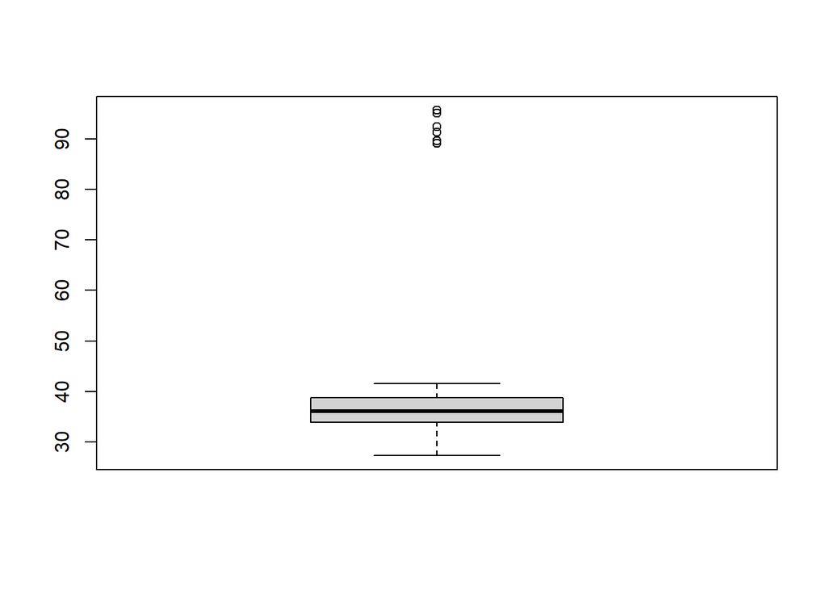

```r
# take only select and integer to look at NA (removing text, dummies, notes, etc.)
if (check_for_shortest_path) {
  if (exists("questions")) {
    names_for_blanks_check <- questions %>%
      filter(grepl("select", type) | type == "integer") %>%
      pull(name)

    cleann$blanks <- cleann %>%
      select(any_of(names_for_blanks_check)) %>%
      check_blanks()

  } else {
    cleann$blanks <- cleann %>%
      check_blanks()
  }

  cleann$blanks %>% boxplot()
}
```

```r
cleann <- cleann[order(cleann$blanks, decreasing = TRUE), ]
```

**NOTE**:  
- This plot shows how many NA the interviews have. You should check values with lots of blanks. As there is not a specific threshold, but you should check interviews for high percentage of blanks. *Dataset with the **blank** column is in the output folder.*

### Check for outliers

```r
if (check_for_outliers) {
  outlier_log <- cleaninginspectoR::find_outliers(cleann) %>%
    mutate(uuid = cleann[[uuid_cleann]][index])

  list_log$outlier_log <- outlier_log

  print_log(outlier_log, "No outlier found")

}
```

| index | value | variable | has_issue | issue_type | uuid |
| --- | --- | --- | --- | --- | --- |
| 552 | 2000000 | monthly_income | TRUE | normal distribution outlier | 2eb73fe1-73ee-4f61-bc6a-8eed735abbed |
| 566 | 1700000 | monthly_income | TRUE | normal distribution outlier | fe08f45c-3c3a-437e-8517-f0db924901b5 |
| 593 | 1900000 | monthly_income | TRUE | normal distribution outlier | 8d1481a3-a23e-4d9f-b1e1-33027b724977 |
| 704 | 1500000 | monthly_income | TRUE | normal distribution outlier | 165f50ee-bd14-4c8d-a76a-a2f1ce9256a4 |
| 786 | 1250000 | monthly_income | TRUE | normal distribution outlier | be6fe4d6-2f9e-4f45-975f-1efcaf873133 |
| 809 | 1250000 | monthly_income | TRUE | normal distribution outlier | d55840ad-391d-4c3c-9513-0f7e7e4f0382 |
| 814 | 1500000 | monthly_income | TRUE | normal distribution outlier | 900e8769-0375-4214-93fa-2de3195f8b38 |
| 992 | 1250000 | monthly_income | TRUE | normal distribution outlier | 95f038e9-ea2a-49e6-9ec2-0091d56d3a1c |
| 1042 | 1500000 | monthly_income | TRUE | normal distribution outlier | 0c7923ce-052a-4f95-9f94-02c7870df013 |
| 1043 | 1200000 | monthly_income | TRUE | normal distribution outlier | 564349bd-edc5-4b04-b11f-92391f51e12f |
| 1141 | 1400000 | monthly_income | TRUE | normal distribution outlier | 8b36ac70-6bf0-425e-99b4-9736532163d8 |
| 1187 | 1300000 | monthly_income | TRUE | normal distribution outlier | 2a8c2661-d522-4211-a81d-47554c38e96c |
| 1202 | 1800000 | monthly_income | TRUE | normal distribution outlier | 9344f9a3-74e6-47c4-82b4-a6984f69da7c |
| 1235 | 1400000 | monthly_income | TRUE | normal distribution outlier | c1e4ad3d-1dc9-4149-a08f-43eb72689cfe |
| 1254 | 1500000 | monthly_income | TRUE | normal distribution outlier | 0255b6ac-4d1d-478b-abbf-4e6d6c21b229 |
| 1439 | 1500000 | monthly_income | TRUE | normal distribution outlier | eee07440-4760-4d13-a0c9-69d654d5a189 |
| 1445 | 1600000 | monthly_income | TRUE | normal distribution outlier | 93b879ec-f3a4-46a5-b2ef-d7569b9fa55a |
| 1561 | 1500000 | monthly_income | TRUE | normal distribution outlier | b937cdd7-63f3-4e29-9191-74b63856fc28 |
| 1686 | 1500000 | monthly_income | TRUE | normal distribution outlier | 966a5254-af8c-4f05-a395-50d8ef42f560 |
| 1691 | 1200000 | monthly_income | TRUE | normal distribution outlier | 79a8a667-89b2-48bb-b6fa-432bd710c8c7 |
| 1729 | 1400000 | monthly_income | TRUE | normal distribution outlier | 663606ca-5bc8-49e1-8dad-c569affbb54b |
| 1756 | 1300000 | monthly_income | TRUE | normal distribution outlier | 2054de91-c3ec-439b-a87b-5467aadb3902 |
| 1771 | 1500000 | monthly_income | TRUE | normal distribution outlier | 3bee6af4-c521-41b4-8a89-8c05d3404c7a |
| 1809 | 1300000 | monthly_income | TRUE | normal distribution outlier | a8fb283e-aa1a-4e3d-b538-e6dd21c30ed1 |
| 1849 | 1200000 | monthly_income | TRUE | normal distribution outlier | c1a6ccf2-a076-479c-8511-74579e3a7aff |
| 1940 | 1500000 | monthly_income | TRUE | normal distribution outlier | 1aaeabcc-afaa-48ab-80c1-a9442a97f452 |
| 2006 | 1350000 | monthly_income | TRUE | normal distribution outlier | 31caaa37-2461-4aee-9f82-e7a639ac9473 |
| 2203 | 1200000 | monthly_income | TRUE | normal distribution outlier | 078a9331-5966-45ba-bf93-93b15745d609 |
| 2269 | 1450000 | monthly_income | TRUE | normal distribution outlier | 5af5dc5f-d5cf-4dc7-aa6f-fd8d4e91fc8f |
| 2328 | 1600000 | monthly_income | TRUE | normal distribution outlier | 6416db31-95a6-482f-a340-bea32a119ea2 |
| 2412 | 1200000 | monthly_income | TRUE | normal distribution outlier | 9839f553-bc24-4c64-969c-8ddd8989a1f0 |
| 678 | 50000 | va_debt_total | TRUE | log normal distribution outlier | c4dcfda8-e9c8-4fac-9dbe-816f418eaf99 |
| 1116 | 50000 | va_debt_total | TRUE | log normal distribution outlier | 29bc28aa-a5e1-4d37-9525-bfbbf971a1f4 |
| 1964 | 29000000 | va_debt_total | TRUE | log normal distribution outlier | c61edafd-b39f-438b-9029-bdf76b96c695 |
| 2154 | 30000000 | va_debt_total | TRUE | log normal distribution outlier | 223e48f0-8cbf-4312-8049-cfab28415dc9 |
| 2335 | 60000 | va_debt_total | TRUE | log normal distribution outlier | 9c938984-d0cb-47b3-bb4c-c1d8db08de49 |
| 2083 | 440000 | amount_other | TRUE | normal distribution outlier | 4e5d5ee3-4c0d-4760-9047-b11bd6fec565 |
| 2083 | 440000 | amount_reported | TRUE | normal distribution outlier | 4e5d5ee3-4c0d-4760-9047-b11bd6fec565 |
| 2176 | 480000 | amount_reported | TRUE | normal distribution outlier | 63c34c1f-9b50-48a7-b136-73b49dbf3bbc |
| 2235 | 480000 | amount_reported | TRUE | normal distribution outlier | 1125c89b-3339-4d67-ad90-7f7dc6fe201d |
| 2314 | 200000 | amount_reported | TRUE | normal distribution outlier | 82272493-08a6-4894-b168-231063c0fe56 |
| 2314 | 40000 | pay_for_fee_yes_iqd | TRUE | log normal distribution outlier | 82272493-08a6-4894-b168-231063c0fe56 |
| 1186 | 120000 | spent_assistance_amount | TRUE | normal distribution outlier | 8b7389f1-a270-4234-a039-ef6dee9e733e |
| 2083 | 440000 | spent_assistance_amount | TRUE | normal distribution outlier | 4e5d5ee3-4c0d-4760-9047-b11bd6fec565 |
| 2176 | 480000 | spent_assistance_amount | TRUE | normal distribution outlier | 63c34c1f-9b50-48a7-b136-73b49dbf3bbc |
| 2235 | 480000 | spent_assistance_amount | TRUE | normal distribution outlier | 1125c89b-3339-4d67-ad90-7f7dc6fe201d |
| 2314 | 200000 | spent_assistance_amount | TRUE | normal distribution outlier | 82272493-08a6-4894-b168-231063c0fe56 |
| 2173 | 2400000 | total_spent_assistance_reusable_items | TRUE | normal distribution outlier | 9674fc5e-d5e9-4fa5-8026-6538cda07d34 |

### Logical check

```r
# if (check_for_logical) {
# #to be done manually
# #######################################################################################################
# #if you have a table with 2 columns : "name" and "check", where "check" is the syntax of the r check #
# #you can try to un-comment this part #
# #######################################################################################################
#
# logical_list_check <- readxl::read_excel("inputs/check_list.xlsx")
#
#
#
# make_check <- function(xx) {
# message(xx[["name"]])
# cleann %>%
# mutate(!!sym(xx[["name"]]) := eval(parse(text = xx[["check"]]))) %>%
# pull(!!sym(xx[["name"]]))
# }
#
#
#
# logical_check_table <- logical_list_check %>%
# apply(1, make_check) %>%
# as.data.frame() %>%
# `names<-`(logical_list_check$name)
#
#
#
# cleann <- cbind(cleann, logical_check_table)
#
#
#
# summary_logical_check <- logical_check_table %>%
# summarise(across(.fns = sum, na.rm=T)) %>%
# t() %>%
# cbind(logical_list_check,.) %>%
# `names<-`(c("name", "check", "n")) %>%
# arrange(desc(n)) %>%
# select(name, n, check)
# summary_logical_check %>% knit_big_table()
# }
```

### Other and translation

```r
if (check_for_others) {
  if (exists("questions")) {
    text_oth <- questions %>%
      filter(type == "text") %>%
      pull(name)

    other_log <- cleann %>%
        select(any_of(text_oth), !!sym(uuid_cleann)) %>%
        pivot_longer(cols = -!!sym(uuid_cleann)) %>%
        filter(!is.na(value)) %>%
        mutate(issue_type = "to could be recoded") %>%
        dplyr::rename(variable = name)

  } else {
    other_log <- cleaninginspectoR::find_other_responses(cleann) %>%
      mutate(uuid = cleann[[uuid_cleann]][index])
  }
  list_log$other_log <- other_log
}
```

This is all the values from text questions.

```r
if (check_for_others) {
  other_log %>%
    arrange(variable, value) %>%
    knit_big_table()
}
```

| _uuid | variable | value | issue_type |
| --- | --- | --- | --- |
| 8bd68925-6eb1-4c3b-ac63-7499b6cf3af0 | assistance_help_other | Send money to his family | to could be recoded |
| 7d7566b0-ea54-4eca-9efe-9c0586767b97 | assistance_help_other | Send money to his family | to could be recoded |
| 7efaaeca-5557-4e0e-8879-be8eac76064d | assistance_help_other | Send money to his family | to could be recoded |
| 114ff66b-5ea2-4abc-a1c4-89c318456638 | assistance_help_other | Send money to his family | to could be recoded |
| c957b522-bbda-49b3-ab2f-6444dbbf5bcb | assistance_help_other | Send money to his family | to could be recoded |
| 2d739151-2371-4597-ba63-efaa3a4df60a | assistance_help_other | Send money to his family | to could be recoded |
| bc0ab737-0af8-4bc6-8f9d-45883d4ccc8b | assistance_help_other | Send money to his family | to could be recoded |
| 37085c33-a665-468a-9f5b-db83e7dc1d97 | assistance_help_other | Send money to his family | to could be recoded |
| 27edf0cd-6eb6-43fb-b28e-735d7488fc81 | assistance_help_other | Send money to his family | to could be recoded |
| ba5fe0f9-0ecb-4b89-a8e9-761ab5308137 | assistance_help_other | Send money to his family | to could be recoded |
| 56ba4843-2766-428b-b83c-196859f5351f | assistance_help_other | Send money to his family | to could be recoded |
| 95d069aa-e7fb-4426-90f4-5d2ff8a6667c | assistance_help_other | Send money to his family | to could be recoded |
| 20c522e0-8107-4922-a6a2-930baccd7604 | assistance_help_other | Send money to his family | to could be recoded |
| 437de97f-2746-48c9-b439-6cfcea018a21 | assistance_help_other | Send money to his family | to could be recoded |
| 328a2516-e411-4f8f-a88c-2481670d7762 | assistance_help_other | Send money to his family | to could be recoded |
| 24526e3c-ef28-4500-8065-c020ad5b0c22 | assistance_help_other | Send money to his family | to could be recoded |
| f9ce24e7-d8c1-4699-b499-be716a9b2ead | assistance_help_other | Send money to his family | to could be recoded |
| 9e4ef4c2-5a67-4558-b212-3a35a928ede6 | assistance_help_other | Send money to his family | to could be recoded |
| 032bce62-df7d-4fe2-be30-5f1f5e64c0f7 | assistance_help_other | Send money to his family | to could be recoded |
| 1437cf7e-17a2-4df5-907a-68d0a2a972d7 | assistance_help_other | Send money to his family | to could be recoded |
| 690e712d-55bb-4c8d-bc1d-afc3b8d2a992 | assistance_help_other | Send money to his family | to could be recoded |
| 44d7abd9-a910-4b7b-89a7-e05978ab46e6 | assistance_help_other | Send money to his family | to could be recoded |
| a0d45635-45de-4345-b355-6055a1a5e867 | assistance_help_other | Send money to his family | to could be recoded |
| 629db9e2-7536-46c9-9721-9c4f996fad7e | assistance_help_other | Send money to his family | to could be recoded |
| 9e0c1e23-1d1a-4ba2-b924-9a01aa305d6e | assistance_help_other | Send money to his family | to could be recoded |
| d526ceb5-ac38-4d9a-b9af-2e006cce09aa | assistance_help_other | Send money to his family | to could be recoded |
| c09aaf49-76f1-47b5-8b29-8ba6b042fff0 | assistance_help_other | Send money to his family | to could be recoded |
| b408c395-af51-44ba-ae4b-74cf66670cf9 | assistance_help_other | Send money to my family | to could be recoded |
| d4af4128-ea15-41fa-ab43-12e100ce6128 | assistance_help_other | Send mony to his family | to could be recoded |
| 7e9107ec-35d4-4c3c-9c0b-8c9835645279 | assistance_help_other | Sent money to his family | to could be recoded |

[output cut: 299 more lines]

This is how many interviews per text question.

```r
if (check_for_others) {
  other_log %>%
    group_by(variable) %>%
    tally(sort = T) %>%
    knit_big_table()
}
```

| variable | n |
| --- | --- |
| payment_round_other | 110 |
| pay_for_fee_yes_why | 104 |
| information_from_who_specify | 38 |
| assistance_help_other | 31 |
| va_coping_specify_before | 11 |
| type_of_poor_service | 7 |
| item_need_coming_winter_other | 4 |
| va_primary_income_sources_other | 4 |
| information_difficulties_cashingissues | 3 |
| safety_why | 3 |
| assistance_source_specify | 2 |
| assistance_specify | 2 |
| coping_other_specify_other | 2 |
| non_compliance_002_other | 2 |
| assistance_not_help_specify | 1 |
| complaint_reason_specify | 1 |
| information_received_speficy | 1 |
| item_needed_other | 1 |
| non_consent | 1 |
| type_difficulties_spending_other | 1 |

The values which are identicals.

```r
if (check_for_others) {
  other_log %>%
    group_by(value) %>%
    tally(sort = T) %>%
    knit_big_table()
}
```

| value | n |
| --- | --- |
| 1 | 108 |
| Fees | 105 |
| Korek sms | 33 |
| Send money to his family | 25 |
| Skip paying the rent of the house | 7 |
| 2 | 2 |
| Savings | 2 |
| Send money to his family | 2 |
| Wood | 2 |
| paid fees to receive the assistance | 2 |
| All the amount was from One Thousand category so many people suffer from it | 1 |
| All the money were from one Thousand category | 1 |
| Asia hawala | 1 |
| Because I do not know how to spent | 1 |
| Because money this amounts are not enough | 1 |
| Because the cash is not enough | 1 |
| Cash assistance from our relatives abroad | 1 |
| Daily income by child labour | 1 |
| Daily temporarily work | 1 |
| Depending on the cash assistance by UNHCR for multi purposes | 1 |
| Depending on the cash assistance by UNHCR for multi purposes that is distributed once every two months. | 1 |
| Except of 50 000IQD was from 5000 IQD category and all the other amount are given by the the category of one Thousand and most of them were very old | 1 |
| Hardware organisation | 1 |
| Harikar Org. | 1 |
| I do not know location | 1 |
| I do not know location name | 1 |
| I don’t know | 1 |
| I don’t want to complain because there is no result or feedback | 1 |
| I received a massage but not it was for another person | 1 |
| Korek SMS | 1 |
| Korek SMS | 1 |
| Korek sms but not sure | 1 |
| My massage was be sent to another person and a massage for another one was sent to me | 1 |
| No | 1 |
| No have phone number of complain | 1 |
| People will give me charity | 1 |
| Renting | 1 |
| Send money to my family | 1 |
| Send mony to his family | 1 |
| Sent money to his family | 1 |
| Sent to my parents | 1 |
| Skip paying the rent of the house in addition on depending on the cash assistance for multi purposes by UNHCR every two months | 1 |
| Some piece ofclothes | 1 |
| The money were old and from one Thousand categories | 1 |
| The owner of exchange office who was distributing money told us that he will pay 235000 IQD if he pay in 5 or ten or other categories of Iraqi Dinar but if he pay by in one Thousand category he pay al… | 1 |
| They told him that they will pay 235000IQD if he receives all the amount by the category of 5 or 10 thousands but if he will recieve amount of one Thousand category they will pay him all the amount of… | 1 |
| We recieved about 200 000 IQD from one Thousand category | 1 |
| We used it for an urgent medical case | 1 |
| Winter clothes | 1 |
| Zakho finance office Was closed, we went to Sumel district for receiving money. | 1 |
| حطب | 1 |

### Deletions

```r
number_cleann_in_dell <- "Check not performed"
number_dell_in_cleann <- "Check not performed"
number_difference_raw_clean_del <- "Check not performed"

if (check_for_deletions) {
  data.frame(n_raw = nrow(raww),
             n_clean = nrow(cleann),
             n_deleted = nrow(dell),
             sum_clean_del = nrow(cleann) + nrow(dell)
             )

  number_cleann_in_dell <- cleann[[uuid_cleann]] %in% dell[[uuid_dell]] %>% sum()
  number_dell_in_cleann <- dell[[uuid_dell]] %in% cleann[[uuid_cleann]] %>% sum()
  number_difference_raw_clean_del <-  abs(nrow(raww) - nrow(cleann) - nrow(dell))

  # if(number_cleann_in_dell != 0)
  #   values_cleann_in_dell <- 0
  #   values_cleann_in_dell <- setdiff(unique(cleann$uuidcleann), unique(dell$uuid_dell))
  #   values_cleann_in_dell <- data.frame(values_cleann_in_dell)
  # if(number_dell_in_cleann != 0)
  #   values_dell_in_cleann <- 0
  #   values_dell_in_cleann  <- setdiff(unique(dell$uuid_dell),unique(cleann$uuid_cleann))
  #   values_dell_in_cleann  <- data.frame(values_dell_in_cleann)
  #
  # if(number_difference_raw_clean_del != 0)
  #   values_raww_in_clean <- 0
  #   values_raww_in_clean <- setdiff(unique(raww$uuid_raw),unique(cleann$uuid_cleann))
  #   values_raww_in_clean <- data.frame(values_raww_in_clean)
  #   values_raw_cleann_dell <- 0
  #   values_raw_cleann_dell <- setdiff(unique(values_raww_in_clean),unique(dell$uuid_dell))
  #   values_raw_cleann_dell <- data.frame(values_raw_cleann_dell)

}
```

Difference between raw, clean and deletion log: 0  
Number of uuid of clean in deleted : 0  
Number of uuid of deleted in clean : 0

## 2. Cleaning log

### Cleaning log

This section checks if the cleaning log has been applied.

```r
if (check_for_cleaning_log) {
  cat("Number of entries in the cleaning log that have the same value in the clean data")
  summary_cleaning$check_clean %>% table(useNA = "ifany")
}
```

```
## Number of entries in the cleaning log that have the same value in the clean data
```

```
## .
## FALSE  TRUE  <NA>
##    30  2433   782
```

**How to read**  
- Old Value refers to your cleaning log old value  
- New Value refers to your cleaning log new value  
- value_clean refers to the value in the clean dataset.  
Cleaning log not applied for 30 entries.  
See below which ones.

```r
if (check_for_cleaning_log) {
  summary_cleaning %>% filter(check_clean == F) %>%
    select(all_of(c(uuid_logg, var_logg, old_value_logg, new_value_logg)), value_clean) %>%
    knit_big_table()
}
```

| uuid | Question | Old Value | New Value | value_clean |
| --- | --- | --- | --- | --- |
| 2eb73fe1-73ee-4f61-bc6a-8eed735abbed | monthly_income | 1900000 | 2000000 | 2e+06 |
| fe4c07f7-7200-4eda-b2f5-3468692f8b21 | va_debt_total | 15000000 | 15000000 | 1.5e+07 |
| 8888196f-1673-49a5-89be-b62c5d5c2255 | monthly_income | 1000000 | 1000000 | 1e+06 |
| c65ce27f-9689-4c7f-ae5c-c0a9cb617b3e | monthly_income | 1000000 | 1000000 | 1e+06 |
| e56b16de-7683-4c0d-a63b-faa8c9f8fcac | monthly_income | 1000000 | 1000000 | 1e+06 |
| 99387a6f-00f2-4387-a86e-61871a964102 | monthly_income | 1000000 | 1000000 | 1e+06 |
| af84058f-5306-4574-950a-b536824749ca | monthly_income | 1000000 | 1000000 | 1e+06 |
| 292e6234-6495-42cb-9091-d26c6c3262a7 | monthly_income | 1000000 | 1000000 | 1e+06 |
| feeb19e9-b785-43fe-a5ad-2fe4ef02ac94 | monthly_income | 0 | 500000 | 5e+05 |
| a71cb629-6f24-4cf3-ba54-6d94f917a26c | dist_date | 45066 | 44915 | 2022-12-20 |
| 34e0a681-e156-468c-abed-5cde27efb619 | dist_date | 45017 | 44930 | 2023-01-04 |
| 8f893204-e733-4a91-a598-9abe1759a2f7 | dist_date | 45068 | 44917 | 2022-12-22 |
| ac71bebc-86cc-4358-8054-07f064467ef0 | dist_date | 45048 | 44959 | 2023-02-02 |
| 28d1cc65-fb99-4a55-92ff-1fb0b5815f32 | va_debt_total | 50000000 | 5000000 | 5e+06 |
| d8504672-e1d5-405f-9b4c-0549817ce39b | va_debt_total | 12000000 | 12000000 | 1.2e+07 |
| 4a512489-0132-4af6-8bfb-b1b0e2315c88 | va_debt_total | 25000000 | 25000000 | 2.5e+07 |
| 3d178e51-cf0c-453d-8650-44a983e7aa7a | va_debt_total | 20000000 | 20000000 | 2e+07 |
| 3103d4ba-0b8f-4999-a34c-ef8b9f417810 | va_debt_total | 20000000 | 20000000 | 2e+07 |
| 340447fd-9ab5-41cf-825e-cea39e203a0a | va_debt_total | 12000000 | 12000000 | 1.2e+07 |
| 223e48f0-8cbf-4312-8049-cfab28415dc9 | va_debt_total | 30000000 | 30000000 | 3e+07 |
| ab310d88-ca2f-483e-a4b7-9d513b76c23d | va_debt_total | 17000000 | 17000000 | 1.7e+07 |
| 7324e7a0-3668-4435-a4da-b3b3502590a5 | va_debt_total | 18000000 | 18000000 | 1.8e+07 |
| c61edafd-b39f-438b-9029-bdf76b96c695 | va_debt_total | 29000000 | 29000000 | 2.9e+07 |
| 767ca2a5-87f5-4311-be54-b051e5ad656a | va_debt_total | 18000000 | 18000000 | 1.8e+07 |
| b40cbcd6-59f0-4798-a84f-80370f68cdba | pay_for_fee_yes_iqd | 20000 | 2000 | 5000 |
| 8d1481a3-a23e-4d9f-b1e1-33027b724977 | monthly_income | 1900000 | 2175000 | 1900000 |
| e50cd305-9918-4f8d-bc04-7e07337cd617 | dist_date | 44876 | 44572 | 2022-12-21 |
| d63e1b94-eb1a-46e7-9026-d83c018f2ce4 | dist_date | 44886 | 44916 | 2022-12-21 |
| b1488247-9021-44cb-a76b-9490100b699c | dist_date | 44886 | 44916 | 2022-01-11 |
| 87126f9a-e72a-4980-862f-de45fd12adf2 | dist_date | 44825 | 44916 | 2022-12-21 |

Cleaning log ambigious for 457 entries. You have a value in your cleaning log but it is NA in the dataset.  
This is a summary per question and per value. (feel free to ignore the obvious ones such as 999, deletion)

```r
if (check_for_cleaning_log) {
  summary_cleaning %>% filter(is.na(check_clean),
                               !!sym(new_value_logg) != "NA") %>%
    group_by(!!sym(var_logg), !!sym(new_value_logg), value_clean) %>% tally(sort = T) %>%
    knit_big_table()
}
```

| Question | New Value | value_clean | n |
| --- | --- | --- | --- |
| non_compliance_002_other | blank | NA | 405 |
| case_id_1 | 0 | NA | 17 |
| Who_give_money_favours | blank | NA | 13 |
| All | Form deleted | NA | 5 |
| case_id_2 | 0 | NA | 4 |
| non_compliance_002_other | 1 | NA | 3 |
| final_date | 44916 | NA | 2 |
| final_date | 44572 | NA | 1 |
| hhh_emplyment_other | blank | NA | 1 |
| hhh_emplyment_status/other | 0 | NA | 1 |
| hhh_emplyment_status/unemployed | 1 | NA | 1 |
| non_compliance_002/not_interested_to_report | 1 | NA | 1 |
| non_compliance_002/other | 0 | NA | 1 |
| pay_cash_out_who | blank | NA | 1 |
| pay_cash_out_who/shopkeeper | blank | NA | 1 |

And the details here.

```r
if (check_for_cleaning_log) {
  cleaning_to_check_na <- summary_cleaning %>% filter(is.na(check_clean),
                               !!sym(new_value_logg) != "NA") %>%
    select(all_of(c(uuid_logg, var_logg, old_value_logg, new_value_logg)), value_clean)
  cleaning_to_check_na %>%
    knit_big_table()
}
```

| uuid | Question | Old Value | New Value | value_clean |
| --- | --- | --- | --- | --- |
| fa49a334-b765-4915-b0b8-4fd756f9644c | pay_cash_out_who | shopkeeper | blank | NA |
| fa49a334-b765-4915-b0b8-4fd756f9644c | pay_cash_out_who/shopkeeper | 1 | blank | NA |
| dac04cc5-3216-4f23-85e3-8aefddb45674 | All | NA | Form deleted | NA |
| 7dd2b31d-eeac-4998-ab61-36e15e9ea7e6 | All | NA | Form deleted | NA |
| 165f50ee-bd14-4c8d-a76a-a2f1ce9256a4 | non_compliance_002_other | It is only an invoice and I don’t need | blank | NA |
| 74b7ad84-d44b-4ffd-befc-2b11fccf6987 | non_compliance_002_other | It’s only an invoice and I don’t need it | blank | NA |
| d4825665-7fa4-4aac-840d-a68e31d03660 | non_compliance_002_other | It’s only an invoice and I don’t need it | blank | NA |
| 828e6c36-5e9f-4c07-b7ea-825817d14ab0 | non_compliance_002_other | It’s only an invoice and l don’t need it | blank | NA |
| cfb1d2da-1b2e-466a-9515-0844b2c68001 | non_compliance_002_other | It’s only an invoice and I don’t need it | blank | NA |
| 2d07209b-7839-4d20-9026-e5ed370a1066 | non_compliance_002_other | It is only an invoice and I don’t need it | blank | NA |
| 9139759f-3748-42e8-9bce-1be2707e1a46 | non_compliance_002_other | It is only an invoice and I don’t need it | blank | NA |
| 1c3a8d89-7f38-4b4c-95f7-54f9c3e05261 | non_compliance_002_other | It is only an invoice and I don’t need it | blank | NA |
| a55167ea-f5dc-460d-8ab2-580ebe6454f8 | non_compliance_002_other | It is only an invoice and I don’t need it | blank | NA |
| 84353f20-319e-474a-9d0d-59739c8bd424 | non_compliance_002_other | It is only an invoice and I don’t need it | blank | NA |
| 12b31f0f-547c-48b4-a0fa-d1d24f8885e5 | non_compliance_002_other | It is only an invoice and I don’t need it | blank | NA |
| 0ccb5ea8-6da2-4310-9429-7b0595955ec6 | non_compliance_002_other | It is only an invoice and l don’t need il | blank | NA |
| e4b3afc1-8f3d-4b30-ade1-d7dbf7aec723 | non_compliance_002_other | It is only an invoice and I don’t need it | blank | NA |
| 261e25ea-a151-4fe3-b6bf-9501639e1fac | non_compliance_002_other | It is only an invoice and l don’t need it | blank | NA |
| dbd77970-f531-45b8-88b7-72f21521083f | non_compliance_002_other | It is only an invoice and I don’t need it | blank | NA |
| f12768c3-f6a7-4526-a2c6-03a5f7cc1af6 | non_compliance_002_other | It is only an invoice and I don’t need it | blank | NA |
| 90ba0158-3c7f-4b0a-bd9a-a8b625fa18d0 | non_compliance_002_other | It is only an invoice and I don’t need it | blank | NA |
| 3ae9c9d8-1edf-4f86-b87e-f2564401815b | non_compliance_002_other | It is only an invoice and I don’t need it | blank | NA |
| fe4c07f7-7200-4eda-b2f5-3468692f8b21 | non_compliance_002_other | It is only an invoice and I don’t need it | blank | NA |
| 604154d9-e3a3-438f-8120-31e671688102 | non_compliance_002_other | It is only an invoice and I don’t need it | blank | NA |
| 0f862b65-cd84-4d53-b1c5-0000be4af6c4 | non_compliance_002_other | It’s only an invoice and I don’t need it | blank | NA |
| 3ed42276-38de-4d6b-9b1f-ad4639f71ac9 | non_compliance_002_other | It is only an invoice and I don’t need it | blank | NA |
| 49be5705-d207-4c09-a729-f5bbda707d7e | non_compliance_002_other | It is only an invoice and I don’t need it | blank | NA |
| e5dd6354-82f9-4973-842a-8d0add81e71b | non_compliance_002_other | It is only an invoice and I don’t need it | blank | NA |
| 8888196f-1673-49a5-89be-b62c5d5c2255 | non_compliance_002_other | It is only an invoice and I don’t need it | blank | NA |
| 9e0c1e23-1d1a-4ba2-b924-9a01aa305d6e | non_compliance_002_other | It is only an invoice and I don’t need it | blank | NA |

[output cut: 427 more lines]

### Raw and Clean

This section checks if there are differences between the raw and the clean dataset that has not been reported.

```
## Number of differences between raw data and clean data that seems not be in the cleaning log
```

```
## .
## FALSE  TRUE
##  5548  1616
```

```r
if (check_for_raw_clean_data) {
  raw_clean_to_check <- raw_clean_compare %>%
    filter(comments == "change was made", in_cleaning_log == F) %>%
    mutate(issue = "value are different from the raw and clean and does not appear in the cleaning log") %>%
    select(- comments)

  raw_clean_to_check %>% knit_big_table()
}
```

|  | uuid | question.name | new.value | old.value | binding | in_cleaning_log | issue |
| --- | --- | --- | --- | --- | --- | --- | --- |
| 1 | 001024b5-c6a8-4062-856a-82c572e0a1f9 | start | 2023-05-14T16:06:58.000+0200 | 2023-05-14 14:06:58.019 | 001024b5-c6a8-4062-856a-82c572e0a1f9-/-start | FALSE | value are different from the raw and clean and does not appear in the cleaning log |
| 2 | 00141237-fa5d-4329-944c-c36041742314 | start | 2023-05-09T15:09:16.000+0200 | 2023-05-09 13:09:16.761 | 00141237-fa5d-4329-944c-c36041742314-/-start | FALSE | value are different from the raw and clean and does not appear in the cleaning log |
| 3 | 005779ec-7131-49ca-b753-80273ecc2ea8 | start | 2023-05-04T15:27:39.000+0200 | 2023-05-04 13:27:39.994 | 005779ec-7131-49ca-b753-80273ecc2ea8-/-start | FALSE | value are different from the raw and clean and does not appear in the cleaning log |
| 4 | 0077fb3b-7066-4d9a-8d3b-39d84d9ff039 | start | 2023-05-26T16:44:48.000+0200 | 2023-05-26 14:44:48.491 | 0077fb3b-7066-4d9a-8d3b-39d84d9ff039-/-start | FALSE | value are different from the raw and clean and does not appear in the cleaning log |
| 5 | 00b3c441-c658-4419-b894-1a008bf61021 | start | 2023-05-24T12:13:31.000+0200 | 2023-05-24 10:13:31.008 | 00b3c441-c658-4419-b894-1a008bf61021-/-start | FALSE | value are different from the raw and clean and does not appear in the cleaning log |
| 6 | 00f5b2cb-fc44-492a-8e08-cea4f7f7d962 | start | 2023-05-11T13:24:22.000+0200 | 2023-05-11 11:24:22.031 | 00f5b2cb-fc44-492a-8e08-cea4f7f7d962-/-start | FALSE | value are different from the raw and clean and does not appear in the cleaning log |
| 7 | 00f6ddf0-5b81-466f-9cc5-ecc327fa195f | start | 2023-05-04T14:58:51.000+0200 | 2023-05-04 12:58:51.105 | 00f6ddf0-5b81-466f-9cc5-ecc327fa195f-/-start | FALSE | value are different from the raw and clean and does not appear in the cleaning log |
| 8 | 016effae-0b50-498b-94ec-7945f1abdf7c | start | 2023-05-18T16:20:44.000+0200 | 2023-05-18 14:20:44.244 | 016effae-0b50-498b-94ec-7945f1abdf7c-/-start | FALSE | value are different from the raw and clean and does not appear in the cleaning log |
| 9 | 017ab2f4-d507-46f9-bbb9-50f295b74ac8 | start | 2023-05-29T12:36:59.000+0200 | 2023-05-29 10:36:59.284 | 017ab2f4-d507-46f9-bbb9-50f295b74ac8-/-start | FALSE | value are different from the raw and clean and does not appear in the cleaning log |
| 10 | 0181898c-ffcd-4af6-b45e-671cae2d415c | start | 2023-05-26T14:10:53.000+0200 | 2023-05-26 12:10:53.195 | 0181898c-ffcd-4af6-b45e-671cae2d415c-/-start | FALSE | value are different from the raw and clean and does not appear in the cleaning log |
| 11 | 01b761c8-87f1-4542-877e-fad52bcddd29 | start | 2023-05-28T12:21:46.000+0200 | 2023-05-28 10:21:46.478 | 01b761c8-87f1-4542-877e-fad52bcddd29-/-start | FALSE | value are different from the raw and clean and does not appear in the cleaning log |
| 12 | 01caacbc-a6dd-41ff-90bc-2e18404750b4 | start | 2023-05-19T17:45:39.000+0200 | 2023-05-19 15:45:39.03 | 01caacbc-a6dd-41ff-90bc-2e18404750b4-/-start | FALSE | value are different from the raw and clean and does not appear in the cleaning log |
| 13 | 01dbe4dd-4385-42f4-abc1-2f8f61df7d32 | start | 2023-05-28T13:03:02.000+0200 | 2023-05-28 11:03:02.618 | 01dbe4dd-4385-42f4-abc1-2f8f61df7d32-/-start | FALSE | value are different from the raw and clean and does not appear in the cleaning log |
| 14 | 01e8b8e6-c0e5-4161-9518-ad78c86350cd | start | 2023-05-21T15:35:14.000+0200 | 2023-05-21 13:35:14.765 | 01e8b8e6-c0e5-4161-9518-ad78c86350cd-/-start | FALSE | value are different from the raw and clean and does not appear in the cleaning log |
| 15 | 01fe2991-4fff-438f-8660-2c10c106436c | start | 2023-05-24T13:35:51.000+0200 | 2023-05-24 11:35:51.183 | 01fe2991-4fff-438f-8660-2c10c106436c-/-start | FALSE | value are different from the raw and clean and does not appear in the cleaning log |
| 16 | 02060ed3-37f5-4aba-9ce2-149ff847c443 | start | 2023-05-28T12:38:52.000+0200 | 2023-05-28 10:38:52.585 | 02060ed3-37f5-4aba-9ce2-149ff847c443-/-start | FALSE | value are different from the raw and clean and does not appear in the cleaning log |
| 17 | 020a8333-bd18-4249-ae90-4997b82e745e | start | 2023-05-10T15:42:00.000+0200 | 2023-05-10 13:42:00.175 | 020a8333-bd18-4249-ae90-4997b82e745e-/-start | FALSE | value are different from the raw and clean and does not appear in the cleaning log |
| 18 | 020d5f86-70dc-4842-a06a-c0cabc902af4 | start | 2023-05-30T16:48:42.000+0200 | 2023-05-30 14:48:42.112 | 020d5f86-70dc-4842-a06a-c0cabc902af4-/-start | FALSE | value are different from the raw and clean and does not appear in the cleaning log |
| 19 | 0255b6ac-4d1d-478b-abbf-4e6d6c21b229 | start | 2023-05-19T15:41:37.000+0200 | 2023-05-19 13:41:37.309 | 0255b6ac-4d1d-478b-abbf-4e6d6c21b229-/-start | FALSE | value are different from the raw and clean and does not appear in the cleaning log |
| 20 | 02c80c88-5456-4f67-89c2-00e8de1aca2a | start | 2023-05-25T16:20:50.000+0200 | 2023-05-25 14:20:50.457 | 02c80c88-5456-4f67-89c2-00e8de1aca2a-/-start | FALSE | value are different from the raw and clean and does not appear in the cleaning log |
| 21 | 02f26876-d789-4a31-98ba-d019daa4ed55 | start | 2023-05-24T14:54:57.000+0200 | 2023-05-24 12:54:57.758 | 02f26876-d789-4a31-98ba-d019daa4ed55-/-start | FALSE | value are different from the raw and clean and does not appear in the cleaning log |
| 22 | 031e5967-1933-497d-9eaa-11f7ff16ad84 | start | 2023-05-31T13:32:02.000+0200 | 2023-05-31 11:32:02.979 | 031e5967-1933-497d-9eaa-11f7ff16ad84-/-start | FALSE | value are different from the raw and clean and does not appear in the cleaning log |
| 23 | 032978f7-1b47-483f-a4e6-e121c1ded639 | start | 2023-06-01T13:48:48.000+0200 | 2023-06-01 11:48:48.044 | 032978f7-1b47-483f-a4e6-e121c1ded639-/-start | FALSE | value are different from the raw and clean and does not appear in the cleaning log |
| 24 | 032bce62-df7d-4fe2-be30-5f1f5e64c0f7 | start | 2023-05-11T13:14:51.000+0200 | 2023-05-11 11:14:51.125 | 032bce62-df7d-4fe2-be30-5f1f5e64c0f7-/-start | FALSE | value are different from the raw and clean and does not appear in the cleaning log |
| 25 | 0363ab76-1036-484a-90ab-d431a1976b16 | start | 2023-05-11T12:24:16.000+0200 | 2023-05-11 10:24:16.623 | 0363ab76-1036-484a-90ab-d431a1976b16-/-start | FALSE | value are different from the raw and clean and does not appear in the cleaning log |
| 26 | 0371753b-a36c-465b-b439-b4c1eb3b0f52 | start | 2023-05-24T17:05:51.000+0200 | 2023-05-24 15:05:51.544 | 0371753b-a36c-465b-b439-b4c1eb3b0f52-/-start | FALSE | value are different from the raw and clean and does not appear in the cleaning log |
| 27 | 037736b9-c896-4805-8d59-a9804f59a41c | start | 2023-05-28T17:09:58.000+0200 | 2023-05-28 15:09:58.919 | 037736b9-c896-4805-8d59-a9804f59a41c-/-start | FALSE | value are different from the raw and clean and does not appear in the cleaning log |
| 28 | 037c099a-e314-4c5f-ad22-12fafe9d2ab2 | start | 2023-05-21T11:47:04.000+0200 | 2023-05-21 09:47:04.153 | 037c099a-e314-4c5f-ad22-12fafe9d2ab2-/-start | FALSE | value are different from the raw and clean and does not appear in the cleaning log |
| 29 | 03aab613-6f25-445c-80d9-c1e8f4a4d53a | start | 2023-05-24T12:44:15.000+0200 | 2023-05-24 10:44:15.117 | 03aab613-6f25-445c-80d9-c1e8f4a4d53a-/-start | FALSE | value are different from the raw and clean and does not appear in the cleaning log |
| 30 | 03b9583d-686c-4127-998f-b4ebb1d49dc2 | start | 2023-05-15T14:51:20.000+0200 | 2023-05-15 12:51:20.843 | 03b9583d-686c-4127-998f-b4ebb1d49dc2-/-start | FALSE | value are different from the raw and clean and does not appear in the cleaning log |

[output cut: 5512 more lines]

```r
library(writexl)
final_log <- list_log %>%
  map(.f = function(xx){xx %>% mutate(across(.fns = as.character))}) %>%
  do.call(bind_rows, .)

final_log %>% writexl::write_xlsx("outputs/review_cleaning_log_part1.xlsx")

cleaning_check <- list(cleaning_to_check = cleaning_to_check,
                       raw_clean_to_check = raw_clean_to_check)

cleaning_check %>% writexl::write_xlsx("outputs/review_cleaning_part2.xlsx")

cleann %>%writexl::write_xlsx("outputs/dataset_with_check.xlsx")
```